# El paquete rgbif de R para búsqueda y recuperación de datos en GBIF

Manuel Vargas

2020-06-25

## Recursos de interés

- Repositorio de rgbif en GitHub: [ropensci/rgbif: Interface to the Global Biodiversity Information Facility API](https://github.com/ropensci/rgbif).
- Documentación de rgbif en CRAN: [CRAN - Package rgbif](https://cran.r-project.org/web/packages/rgbif/).
- Tutorial de rgbif en rOpenScience: [Introduction to rgbif - rOpenSci:rgbif](https://docs.ropensci.org/rgbif/articles/rgbif.html).
- Documentación del API de GBIF: [GBIF REST API](https://www.gbif.org/developer/summary).
- Lista curada de API: [A Curated List of 100 Cool and Fun Public APIs to Inspire Your Next Project](https://medium.com/better-programming/a-curated-list-of-100-cool-and-fun-public-apis-to-inspire-your-next-project-7600ce3e9b3).

## Introducción

El paquete rgbif del lenguaje de programación [R](https://www.r-project.org/) proporciona acceso a los datos compartidos a través de la interfaz de programación de aplicaciones de la [Infraestructura Mundial de Información en Biodiversidad (GBIF)](https://www.gbif.org/).

Una [interfaz de programación de aplicaciones (API, *Application Programming Interface*)](https://en.wikipedia.org/wiki/Application_programming_interface) es un conjunto de rutinas que brindan acceso a la funcionalidad contenida en un paquete de software, de manera que pueda pueda ser utilizada desde otros programas. En la actualidad, es común ofrecer acceso a los datos de una empresa u organización a través de un API que puede invocarse a través de solicitudes [HTTP (*HyperText Transfer Protocol*, Protocolo de transferencia de hipertexto)](https://en.wikipedia.org/wiki/Hypertext_Transfer_Protocol), el cual es el protocolo de comunicación que se utiliza en la Web.

El [API de GBIF](https://www.gbif.org/developer/summary) proporciona acceso a varios tipos de datos compartidos a través de GBIF, tales como especies, registros de presencia, mapas y noticias. El API puede invocarse a través de direcciones web (ej. https://api.gbif.org/v1/occurrence/search?scientificname=Puma+concolor). Los datos son retornados por el API en formato [*JavaScript Object Notation* (JSON)](https://www.json.org/).

El paquete `rgbif` implementa funciones en R que acceden el API de GBIF, lo que facilita sustancialmente el acceso a los datos de GBIF desde R. `rgbif` es parte de [rOpenSci](https://ropensci.org/), una iniciativa que impulsa la investigación reproducible por medio de datos abiertos y software reutilizable.

## Preparativos

Instalación de paquetes:

```r
# Instalación de rgbif
install.packages("rgbif")

# Instalación de protolite
install.packages("protolite")
```

Carga de paquetes:

```r
# Carga de sf
library(sf)

# Carga de raster
library(raster)

# Carga de rgbif
library(rgbif)

# Carga de protolite
library(protolite)
```

## Uso básico

### Conteo de registros de presencia

La función [occ_count()](https://docs.ropensci.org/rgbif/reference/occ_count.html) retorna la cantidad de registros de presencia de acuerdo con criterios como código del taxón (*taxonKey*), tipo de registro (*basisOfRecord*), país y año, entre otros.

Ejemplos de uso de `occ_count`:

```r
# Total de registros de presencia en GBIF
occ_count()
```

```
## [1] 1423093841
```

```r
# Cantidad de registros georreferenciados
occ_count(georeferenced = TRUE)
```

```
## [1] 1326487005
```

```r
# Cantidad de registros ubicados en Costa Rica
## Obtención del código del país
cr_isocode <- isocodes[grep("Costa Rica", isocodes$name), "code"]
## Conteo
occ_count(country=cr_isocode)
```

```
## [1] 11771591
```

```r
# Cantidad de registros de Phascolarctos cinereus (koala) ubicados en Australia, georreferenciados
## Obtención del código del taxón
name <- name_backbone(name='Phascolarctos cinereus', rank='species')
name[, c('usageKey', 'scientificName')]
```

```
## # A tibble: 1 x 2
##   usageKey scientificName
##      <int> <chr>
## 1  2440012 Phascolarctos cinereus (Goldfuss, 1817)
```

```r
## Conteo
occ_count(taxonKey = 2440012,
          country = 'AU',
          georeferenced = TRUE
)
```

```
## [1] 94084
```

### Búsqueda de registros de presencia

Las funciones [occ_search()](https://docs.ropensci.org/rgbif/reference/occ_search.html) y [occ_data()](https://docs.ropensci.org/rgbif/reference/occ_data.html) retornan los registros de presencia que cumplen con criterios como nombre científico, país, continente, fecha y otros.

`occ_search` retorna un resumen de resultados como los del paquete [dplyr de Tidyverse](https://dplyr.tidyverse.org/), mientras que `occ_data` está optimizada para ser más eficiente.

Ambas funciones retornan un **máximo de 100000** registros en cada llamada.

Ejemplos de uso de `occ_search` y `occ_data`:

```r
# Registros de presencia de manigordos en Costa Rica, georreferenciados y sin problemas detectados de georreferenciación (ej. coordenadas invertidas)
occ_search(
  scientificName = 'Leopardus pardalis',
  country = 'CR',
  hasCoordinate = TRUE,
  hasGeospatialIssue = FALSE
)
```

```r
# Consulta con lista de campos para desplegar
occ_search(
  scientificName = 'Leopardus pardalis',
  country = 'CR',
  hasCoordinate = TRUE,
  hasGeospatialIssue = FALSE,
  fields = c('scientificName', 'decimalLongitude', 'decimalLatitude')
)
```

```
## Records found [35]
## Records returned [35]
## No. unique hierarchies [1]
## No. media records [35]
## No. facets [0]
## Args [hasCoordinate=TRUE, hasGeospatialIssue=FALSE, limit=500, offset=0,
##      scientificName=Leopardus pardalis, country=CR,
##      fields=scientificName,decimalLongitude,decimalLatitude]
## # A tibble: 35 x 3
##    scientificName                      decimalLongitude decimalLatitude
##    <chr>                                          <dbl>           <dbl>
##  1 Leopardus pardalis (Linnaeus, 1758)            -83.2            8.27
##  2 Leopardus pardalis (Linnaeus, 1758)            -83.0            9.73
##  3 Leopardus pardalis (Linnaeus, 1758)            -83.8            9.75
##  4 Leopardus pardalis (Linnaeus, 1758)            -83.3            8.41
##  5 Leopardus pardalis (Linnaeus, 1758)            -84.0            9.42
##  6 Leopardus pardalis (Linnaeus, 1758)            -85.3            9.86
##  7 Leopardus pardalis (Linnaeus, 1758)            -85.6           10.9
##  8 Leopardus pardalis (Linnaeus, 1758)            -85.4           10.2
##  9 Leopardus pardalis (Linnaeus, 1758)            -83.4            8.61
## 10 Leopardus pardalis (Linnaeus, 1758)            -83.7            8.64
## # ... with 25 more rows
```

### Mapas

La función [mvt_fetch()](https://docs.ropensci.org/rgbif/reference/mvt_fetch.html) es un *wrapper* al [API de mapas de GBIF](https://www.gbif.org/es/developer/maps).

```r
# Consulta para retornar el mapa
m <- mvt_fetch(taxonKey = 2440012)

# Tipo de datos del objeto retornado
class(m)
```

```
## [1] "sf"         "data.frame"
```

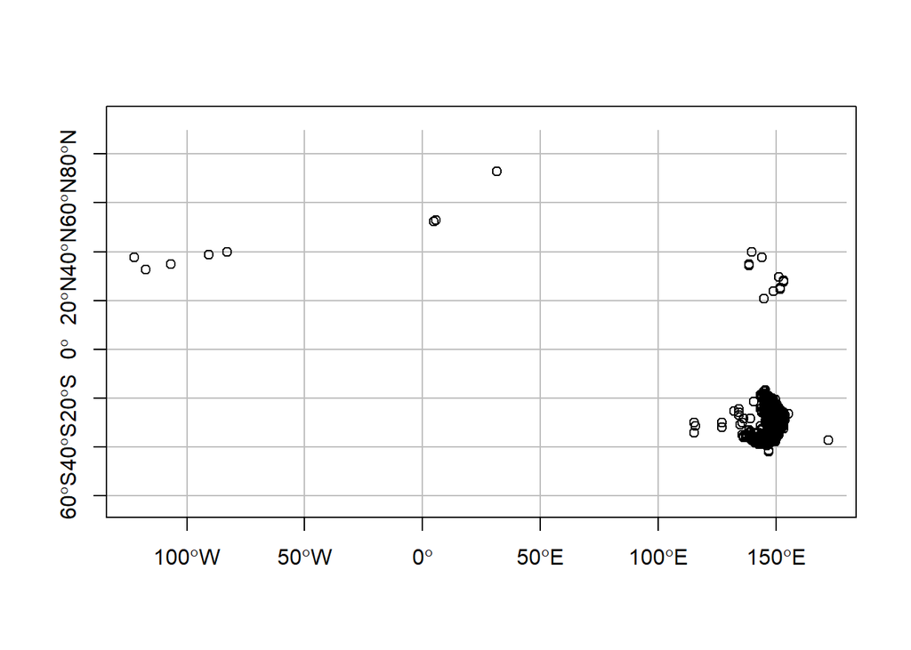

```r
# Mapeo
plot(m$geometry, axes = TRUE, graticule = TRUE)
```

```r
#plot(st_crop(m, c(xmin=-150, xmax=-125, ymin=-60, ymax=-20)))
```

## Uso en combinación con sf y raster

Obtención de datos:

```r
# Registros de presencia de koalas en Oceanía
phascolarctos_cinereus_gbif <-
  occ_search(
    scientificName = 'Phascolarctos cinereus',
    country = 'AU',
    hasCoordinate = TRUE,
    hasGeospatialIssue = FALSE,
    fields = c('scientificName', 'decimalLongitude', 'decimalLatitude'),
    limit = 1500
  )

# Clase de los datos retornados por occ_search()
class(phascolarctos_cinereus_gbif)
```

```
## [1] "gbif"
```

```r
class(phascolarctos_cinereus_gbif$data)
```

```
## [1] "tbl_df"     "tbl"        "data.frame"
```

```r
# Conversión a objeto sf
phascolarctos_cinereus_sf <-
  st_as_sf(phascolarctos_cinereus_gbif$data,
           coords = c("decimalLongitude", "decimalLatitude"),
           crs = 4326
  )


# Capa de altitud
altitude <- getData("worldclim", var="alt", res=10)
```

Mapeo:

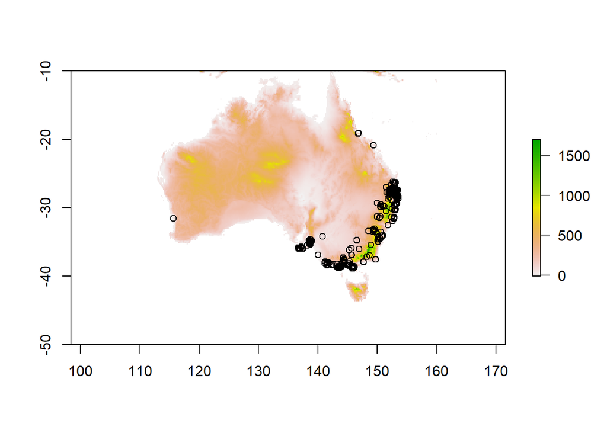

```r
# Mapeo
plot(altitude, ext = extent(110, 160, -50, -10), reset=FALSE)
plot(phascolarctos_cinereus_sf, col='black', add=TRUE)
```